# Visual and Statistical Thinking

A case study report of Tufte’s paper

## Motivation

This document seeks to peel back the layers of successful information presentation, and define critical features of effective data visualizations. By comparing an example of successful data communication with an example of failed data communication, a set of data visualization best practices can be defined.

## Dr. John Snow and the Cholera Epidemic

### Background

- In 1854, there was a sudden outbreak of cholera in central London near Broad Street (~500 people died in 10 days)
- Dr. John Snow suspected a water pump on Broad Street was the cause
- Initial tests of the water revealed nothing suspicious
- John Snow noticed that on the list of 83 deaths he obtained, *only 6 of them did not drink the Broad Street pump water*
- By constructing effective visual representations of the data he collected, Dr. Snow was able to effectively accomplish the task of discovering the mechanism of cholera infection, and proved that cholera is transmitted by water, not air

### Recipe for Effectiveness

- John Snow had studied epidemics as part of his life work, and therefore had deep knowledge of epidemic patterns, which contributed to his correct hypothesis
- However, being correct wasn’t enough: his information delivery method had to effectively convey the evidence to the public, who generally maintained the opposite theory (that cholera was airborne)

#### *Appropriate* data context

- **Inappropriate Context**: the data Snow obtained was ordered by death date as in the image below. Tufte states “the passage of time is a poor explanatory variables, practically useless in discovering a strategy of how to intervene and stop the epidemic”[^1]

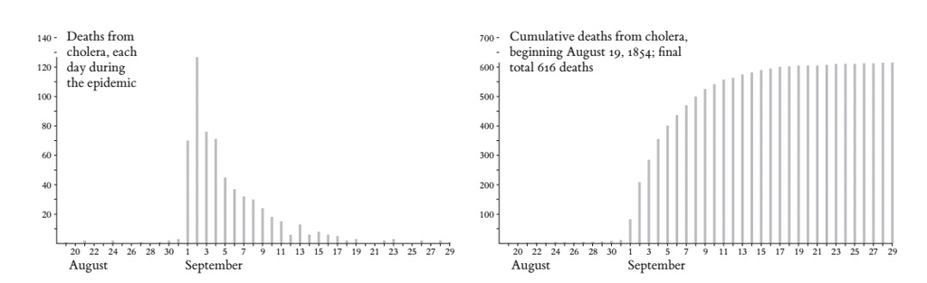

  Figure 1: Time Series Representation of Cholera Data

- **Appropriate Context**: Since Snow’s hypothesis was that a spatial feature (the pump) was the cause of Cholera, he produced a spatial representation of the data instead of using the temporal report
- The bars (||||) represent deaths from Cholera and the dots represent pump locations. Note: the Broad Street pump is adjacent to the “d” in the word “Broad”

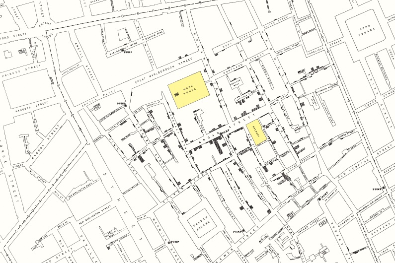

  Figure 2: Spatial Representation of the Data

#### Using *quantitative comparisons*

- A critical feature of extracting patterns from data is using quantitative comparisons/controls

[figure not shown]

  Figure 3: Qualitative Comparisons

- Dr. John Snow’s famous map visualization utilizes the color channel to highlight two “control” cases as shown in Figure 3.
  1. The Brewery
     - After discussion with the owner of the Brewery, Mr. Higgins, Dr. Snow learned “Mr. Higgins believes [the employees] do not drink water at all” since they are allowed the drink the malt liquor.[^2]
  2. The Work House
     - The Workhouse on Poland Street had its own well inside the building, so the inmates never ventured to the Broad Street pump to get water

#### Careful Consideration of Alternatives: An Exercise in Humility pt. 1

- When evaluating cholera deaths that occurred farther from the Broad Street pump (outliers), John Snow discovered that they actually did relate to the Broad Street pump (attended school nearby, favored the water flavor from the Broad Street pump, etc.)
- The least convincing aspect of Snow’s work is the most celebrated - when the Broad Street pump handle was removed. This moment has been interpreted to be the turning point for the Cholera epidemic, although the evidence is weak as seen in figure 4 below.

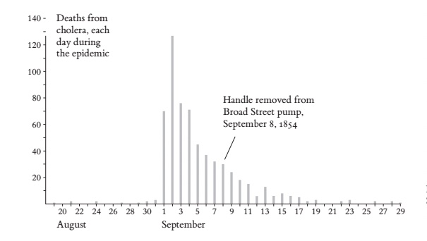

  Figure 4: Cholera Climax

#### Possibility of Error: An Exercise in Humility pt. 2

- **Data Integrity**: John Snow’s analysis of the spatial distribution of cholera cases was accompanied by an analysis of data quality in order to reassure readers that the story presented in his visualizations were accurate an unperturbed by the possibility of bias
- **Representational Integrity**: John Snow’s map suffered from one particularly dangerous shortcoming - it did not account for population density. In the case where the population of central London was distributed the same way cholera deaths were, the “map would have merely repeated the unimportant fact that more people lived near the Broad Street pump than elsewhere.”[^3]
  - The population of central London was distributed more or less uniformly so this concern did not manifest, and John Snow did address this in textual analysis, but the possibility of misrepresenting rates on the map visual was a shortcoming
- **Misleading Aggregations**: As an aside, if the time-series plot of cholera deaths over time were aggregated to the weekly granularity (Figure 5) instead of daily granularity (Figure 4), the intervention of removing the Broad Street pump handle appears to be *the* critical moment in the 1854 London cholera story.

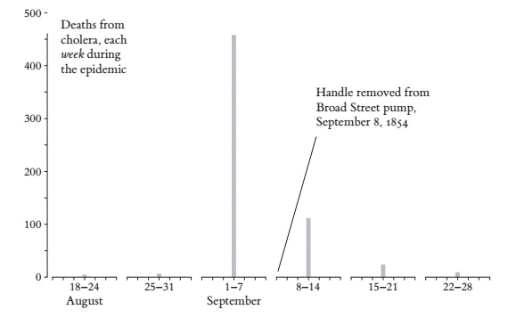

  Figure 5: Misleading Aggregations

### Concluding Remarks

- Visualization effectiveness requires the data be represented:
  1. In the appropriate context as defined by the task abstraction,
  2. Using quantitative comparisons to underscore the possible mechanisms of action
  3. With a robust consideration of alternative explanations, and
  4. With a discussion of potential data integrity issues and humility

## The Decision to Launch the Space Shuttle Challenger

### Background

- In 1986, the space shuttle Challenger exploded 73 seconds after the rockets were ignited because the weather was too cold for the o-ring mechanisms to maintain enough resiliency to prevent fuel leakage
- The night before the launch, the engineers of the Challenger unsuccessfully presented a series of 13 highly ineffective visualizations aimed at preventing the scheduled launch
- By creating visual analyses that disregarded the task at hand (namely, showing the effect cold temperatures have on the structural integrity of o-ring mechanisms), the engineers failed to effectively convey critical information to the decision makers at NASA

### Recipe for Failure

#### Nonexistent Ownership:

- The title chart provided by the Thiokol engineers did not list any of the engineers’ names, potentially inducing a sense of doubt in the consumers of the information to come

#### Missing Critical Context in Task Definition:

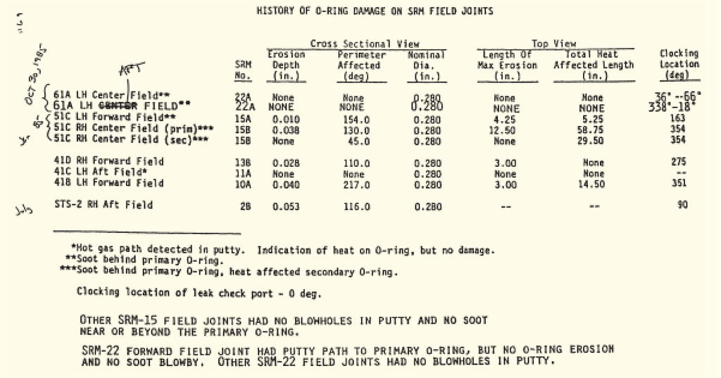

  Figure 6: First Failed Thiokol Chart

- The following charts provided by the engineers continued to neglect describing the likely mechanism of action (temperature) in favor of technical jargon that was irrelevant to the intended task (see Figure 7 below, if it makes no sense, that’s the point)

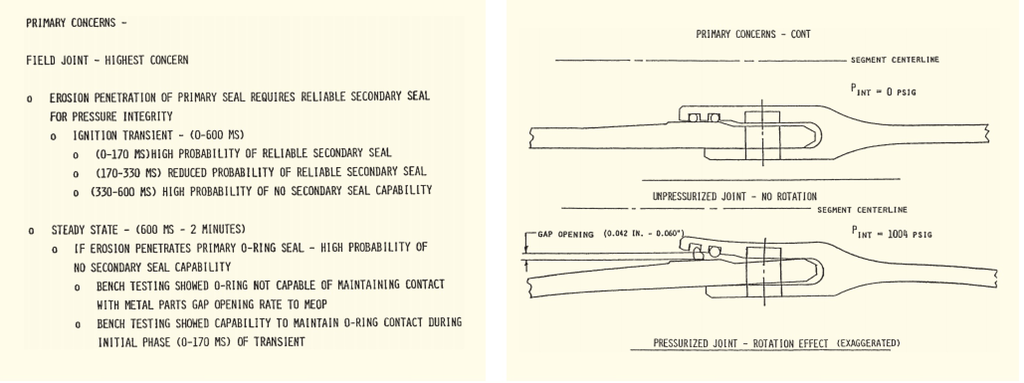

  Figure 7: Additional Irrelevant Thiokol Charts

#### Ineffective Magnitude Channel Application

- When temperature finally entered the visual analysis included in the charts, a highly ineffective/nonexistent magnitude channel was used as seen in Figure 8

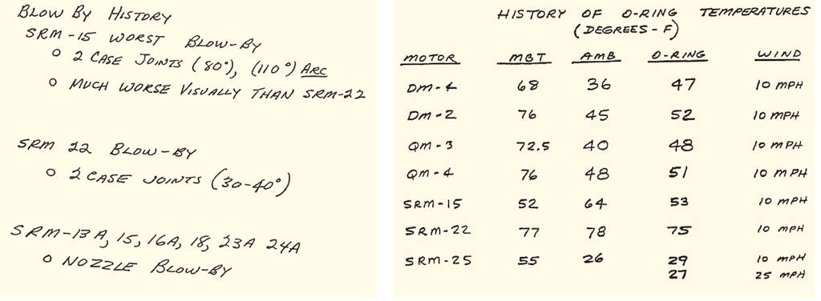

  Figure 8: Ineffective Channel Application

- The subsequent presidential investigation that continued to use visualizations that obscured the task with improper visual channel application (see Figure 9)

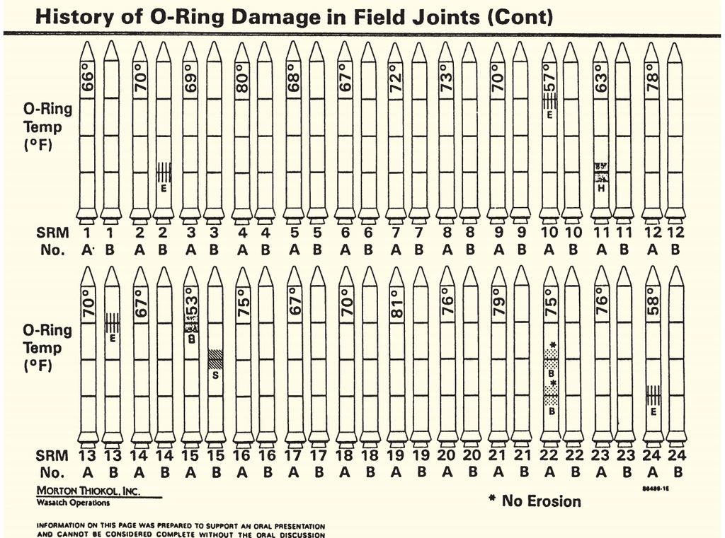

  Figure 9: Ineffective Channel Usage

- Figure 9 has other issues that make it difficult to decipher
  1. **Missing legend**: the chart developers thought readers would memorize legend from prior visual)
  2. **“Chartjunk”**[^4]: more focus was spent drawing mini rockets than effectively highlighting the affect temperature has on o-ring integrity
  3. **Wrong order:** the rockets are ordered by launch date, not by temperature, therefore it becomes impossible to see the relationship between temperature and o-ring integrity

#### Cherry-Picking Quantitative Comparisons

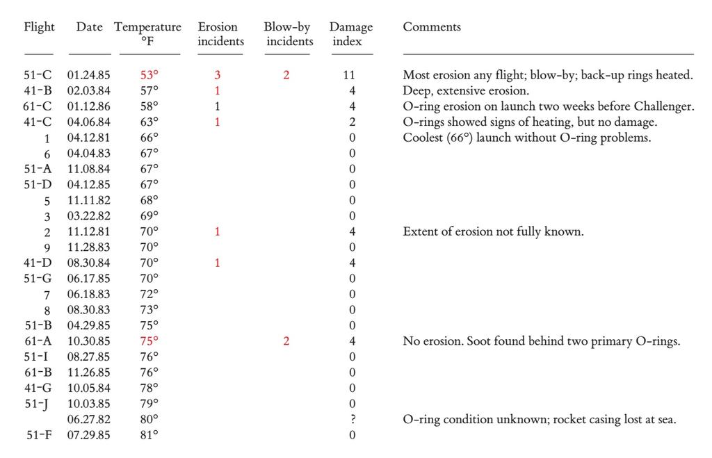

  Figure 10: Appropriate Context

#### Possible Alternative Solutions:

- Figure 11 below demonstrates a far more effective visualization that fixes the flaws mentioned above:
  1. The context is immediately apparent by simply reading the axis titles
  2. Temperature is the ordered x-axis attribute that utilized position on a common scale, the most effective channel for presenting magnitude data
  3. *All* previous launches are shown, not just those that experience o-ring damage

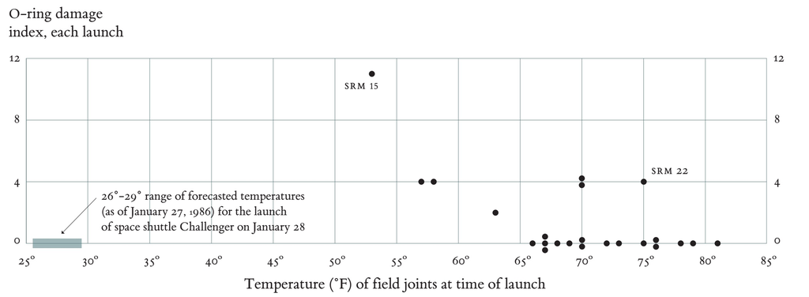

     Figure 11: Reworked Effective Visualization

- This visualization immediately provides evidence that launching the challenger was a gigantic mistake; as Tufte states, “had the correct scatterplot or data table been constructed, no one would have dared to risk the Challenger in such cold weather.”[^5]

### Concluding Remarks

- Visualization effectiveness will be degraded when the data is:
  1. Not visualized in context as defined by the task abstraction,
  2. Not appropriately represented with effective channels
  3. Not quantitatively compared to an appropriate and complete universe of valid comparables
  4. Not considered in the context of possible alternative explanations
[^1]: Pg. 7
[^2]: Pg 9
[^3]: Pg 13
[^4]: Pg 26
[^5]: Pg 30